# Estudio de factores asociados al rendimiento académico de los estudiantes de UTEC en el período 2022-2 durante la modalidad presencial

#### **¿Cuál es la probabilidad de que un estudiante de UTEC duerma más de 8 horas al día?**

```r
round(pexp(8, rate=Lambda, lower.tail=FALSE),2)
```

```
## [1] 0
```

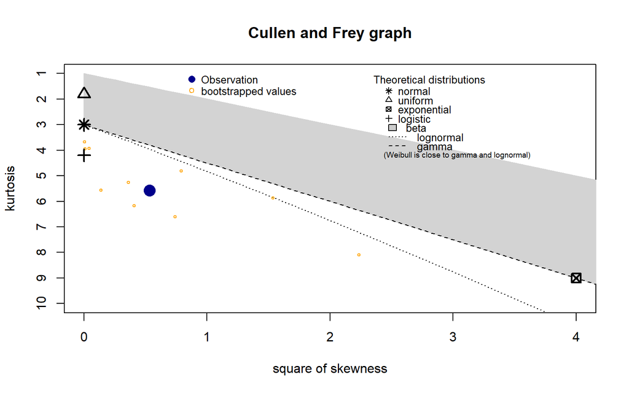

```
## summary statistics
## ------
## min:  2   max:  12
## median:  6
## mean:  5.812207
## estimated sd:  1.300378
## estimated skewness:  0.7305782
## estimated kurtosis:  5.583097
```

```r
descdist(DatosG7$Horas_dormir, boot = 10)
```

#### **¿Cuál es la probabilidad de obtener una calificación de nivel estrés superior al nivel 6 dado que un estudiante durmió más o igual que 7 horas?**

```r
ValH2<-7
round((sum((N>ValN)&(H>=ValH2))/n)/(sum(H>=ValH2)/n),2)
```

```
## [1] 0.46
```

```r
# 46 %
```

## Análisis de la variable `Preferencia_mod`

**Evento:** Los estudiantes de UTEC tienen preferencias respecto a las modalidades en la que se brindan las clases tanto virtuales, híbridas y presenciales.

#### **De los encuestados (213) ¿Cuál es la probabilidad que 10 prefieran la modalidad presencial?**

**Variable aleatoria:**

- $\mathbb{X}$: Número de alumnos que prefieren la modalidad presencial
- $\mathbb{P}$: Probabilidad de que los alumnos prefieran la modalidad presencial

**Usamos el modelo binomial:**

$\mathbb{X}\sim \mathsf{Bin}(213,p)$

```r
p<-sum(DatosG7$Preferencia_mod=="Presencialidad") /nrow(DatosG7)
p
```

```
## [1] 0.2253521
```

```r
dbinom(10,213,0.23)
```

```
## [1] 1.606131e-13
```

Observamos que existe una probabilidad menor a 0.001% que 10 de los 213 encuestados prefieran la modalidad presencial.

Para analizar mejor la distribución de esta probabilidad observemos la siguiente gráfica:

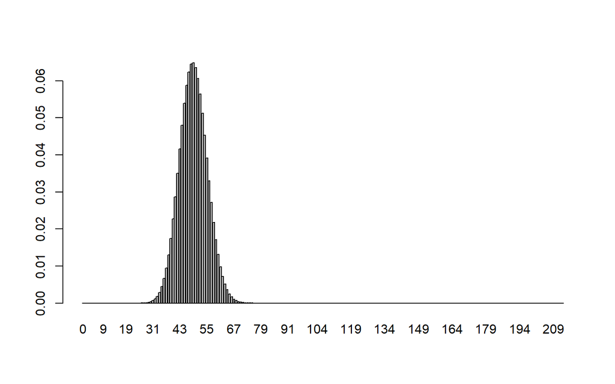

```r
barplot(dbinom(0:213,size=213,prob=0.23),names.arg=c(0:213))
```

### **Así mismo para la modalidad:**

#### **“Híbrida”**

**Variable aleatoria:**

- $\mathbb{X}$: Número de alumnos que prefieren la modalidad híbrida
- $\mathbb{P}$: La probabilidad de que los alumnos prefieran la modalidad híbrida

**Usamos el modelo binomial:**

$\mathbb{X}\sim \mathsf{Bin}(213,p)$

```r
p<-sum(DatosG7$Preferencia_mod=="Hibrido") /nrow(DatosG7)
p
```

```
## [1] 0.6197183
```

```r
dbinom(10,213,0.62)
```

```
## [1] 1.781855e-71
```

Observamos que existe una probabilidad menor a 0.001% que 10 de los 213 encuestados prefieran la modalidad híbrida.

Para analizar mejor la distribución de esta probabilidad observemos la siguiente gráfica:

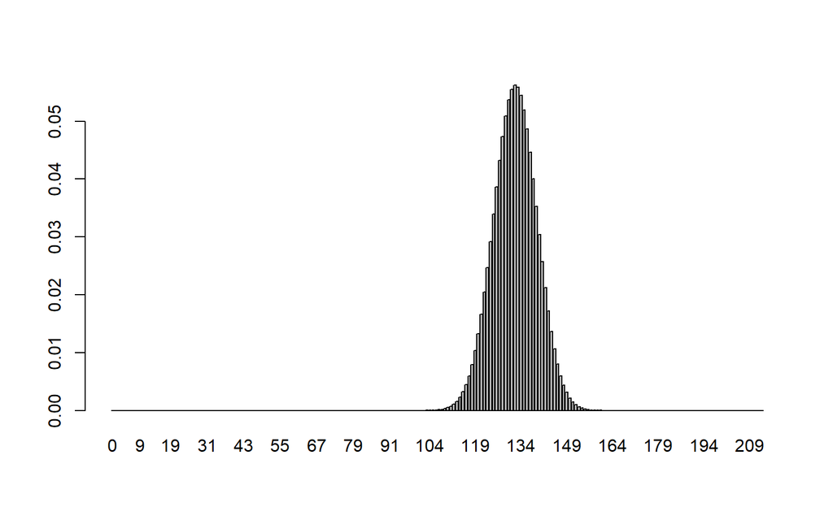

```r
barplot(dbinom(0:213,size=213,prob=0.62),names.arg=c(0:213))
```

#### **“Virtual”**

**Variable aleatoria:**

- $\mathbb{X}$: Número de alumnos que prefieren la modalidad virtual
- $\mathbb{P}$: La probabilidad de que los alumnos prefieran la modalidad virtual

**Usamos el modelo binomial:**

$\mathbb{X}\sim \mathsf{Bin}(213,p)$

```r
p<-sum(DatosG7$Preferencia_mod=="Virtualidad")/nrow(DatosG7)
p
```

```
## [1] 0.1549296
```

```r
dbinom(10,213,0.15)
```

```
## [1] 1.15835e-06
```

Observamos que existe una probabilidad menor a 0.001% que 10 de los 213 encuestados prefieran la modalidad virtual.

Para analizar mejor la distribución de esta probabilidad observemos la siguiente gráfica:

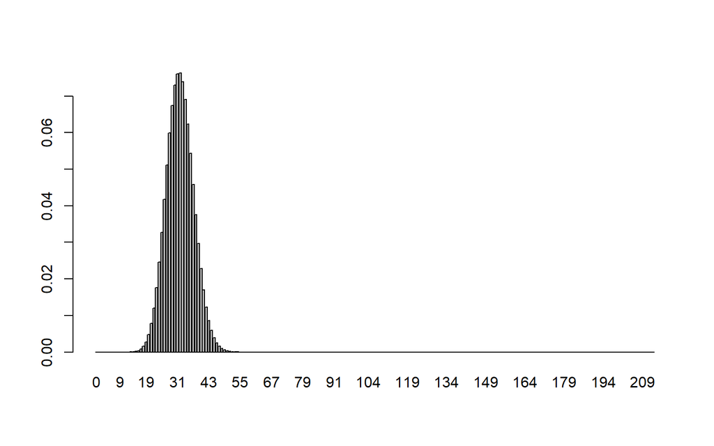

```r
barplot(dbinom(0:213,size=213,prob=0.15),names.arg=c(0:213))
```

Entonces, es mucho mas probable que los alumnos prefieran las modalidad híbrida que la demás modalidades, mientras que la diferencia entre la modalidad presencial y la virtual, son casi mínimas.

## Análisis de `Seguridad_dis`, `Hora_mas_temprana` y `Hora_mas_tarde`

**Notas:**

- **“Tarde”** es las horas entre 12 pm y 11:59 pm.
- Seguridad percibida -> 0 es muy malo y 10 es muy bueno.

#### ¿Cuál es la probabilidad de que un estudiante tenga una percepción de nivel de seguridad mayor o igual a 5 en la hora de la clase más temprana en la mañana?

La probabilidad de que un estudiante tenga una percepción de nivel de seguridad mayor o igual a 5 en la hora de la clase más temprana en la mañana lo vamos a definir como **$P_{\mathbb{sm}}$**.

Seleccionamos la hora de la clase más temprana en la mañana y lo asignamos a la variable `Horatemprana`:

```r
Horatemprana <- min(unique(DatosG7$Hora_mas_temprana))
Horatemprana
```

```
## [1] 7
```

En la variable `Alumnossieteam` se encuentran los alumnos que tienen clases a las 7 de la mañana:

```r
# Percepción de la seguridad de los estudiante que tienen clases a las 7 de la mañana
Alumnossieteam <- DatosG7%>%filter(DatosG7$Hora_mas_temprana==7)
```

Utilizamos la siguiente fórmula de probabilidad condicional:

$$\begin{aligned}
Sean~~A:&~Percepción~de~seguridad~mayor~o~igual~a~5\\
B:&~Total~de~alumnos~que~asisten~a~las~7~am\\
\\Entonces~~&P_{\mathbb{sm}}(A\big|B)=\frac{P(A~\cap B)}{B}\\
\\Donde~~&P(A~\cap B)={\text{Casos a favor}}\\
\\Conclusión~~&P_{\mathbb{sm}}(A\big|B)=\frac{P(A~\cap
B)}{B}=\frac{\text{Casos a favor}}{\text{Casos totales}}\\
\end{aligned}$$

Los casos a favor lo asignamos a la variable `Casosfavor`:

```r
# SMmayoracinco contiene a los estudiante que tienen clases a las 7 de la mañana, la percepción es mayor o igual a 5
SMmayoracinco <- Alumnossieteam%>%filter(Alumnossieteam$seguridad_dis>=5)
Casosfavor <- nrow(SMmayoracinco)
Casosfavor
```

```
## [1] 96
```

Los casos totales lo asignamos a la variable `CasosTotalesM`:

```r
CasosTotalesM <- nrow(Alumnossieteam)
CasosTotalesM
```

```
## [1] 136
```

Intercambiamos los valores:

$$P_{\mathbb{sm}}(A\big|B)=\frac{96}{136}=0.71=71\%$$

Obtenemos que es de 71% la probabilidad de que un estudiante tenga una percepción de nivel de seguridad mayor o igual a 5 en la hora de la clase más temprana en la mañana.

#### ¿Cuál es la probabilidad de que un estudiante tenga una percepción de nivel de seguridad igual menor a 5 en la hora de la clase más tarde en la tarde o noche?

A la probabilidad de que un estudiante tenga una percepción de nivel de seguridad menor a 5 en la hora de la clase más tarde en la tarde o noche lo vamos a definir como **$P_{\mathbb{stm}}$**.

```r
Horatarde <- min(unique(DatosG7$Hora_mas_tarde))
Horatarde
```

```
## [1] 14
```

```r
# Percepción de la seguridad de los estudiante que tienen clases a las 22 de la noche
Alumnosdiezpm <- DatosG7%>%filter(DatosG7$Hora_mas_tarde==22)
```

Utilizamos la siguiente fórmula de probabilidad:

$$\begin{aligned}
Sean~~A:&~Percepción~de~seguridad~menor~a~5\\
B:&~Total~de~alumnos~que~asisten~a~las~22~pm\\
\\Entonces~~&P_{\mathbb{stm}}(A\big|B)=\frac{P(A~\cap B)}{B}\\
\\Donde~~&P(A~\cap B)={\text{Casos a favor}}\\
\\Conclusión~~&P_{\mathbb{stm}}(A\big|B)=\frac{P(A~\cap
B)}{B}=\frac{\text{Casos a favor}}{\text{Casos totales}}\\
\end{aligned}$$

Los casos a favor lo asignamos a la variable `Casosfavor`:

```r
# SNigualacero contiene a los estudiante que tienen clases a las 22 de la noche, la percepción menor a 5
SNigualacero <- Alumnosdiezpm%>%filter(Alumnosdiezpm$seguridad_dis<=5)
Casosfavor <- nrow(SNigualacero)
Casosfavor
```

```
## [1] 40
```

Los casos totales lo asignamos a la variable `CasosTotalesM`:

```r
CasosTotalesN <- nrow(Alumnosdiezpm)
CasosTotalesN
```

```
## [1] 75
```

Intercambiamos los valores:

$$P_{\mathbb{stm}}(A\big|B)=\frac{40}{75}=0.53=53\%$$

## Análisis de la moda de la variable `Creditos` y `Horas_estudiar_dia`

#### **¿Cuál es la probabilidad que un estudiante lleve entre 20 y 21 créditos (moda), y estudie más de 3 horas al día?**

Almacenamos los datos de la variable `Creditos` en la variable C:

```r
C<-DatosG7$Creditos
```

Almacenamos la variable `Horas_estudiar_dia` en la variable H:

```r
H<-DatosG7$Horas_estudiar_dia
```

Hallamos la cantidad de personas que estudiantes entre **“3 a 4 horas diarias a más”**:

```r
MH<-sum(DatosG7$ Horas_estudiar_dia=="3 horas a 4 horas")+sum(DatosG7$ Horas_estudiar_dia=="4 horas a 5 horas")+sum(DatosG7$ Horas_estudiar_dia=="5 horas a 6 horas")+sum(DatosG7$ Horas_estudiar_dia=="6 horas a 7 horas")+sum(DatosG7$ Horas_estudiar_dia=="7 horas a 8 horas")+sum(DatosG7$ Horas_estudiar_dia=="8 horas a 9 horas")+sum(DatosG7$ Horas_estudiar_dia=="9 horas a 10 horas")+sum(DatosG7$ Horas_estudiar_dia=="10 horas a 11 horas")+sum(DatosG7$ Horas_estudiar_dia=="11 horas a 12 horas")+sum(DatosG7$ Horas_estudiar_dia=="12 horas a 13 horas")
MH
```

```
## [1] 132
```

Hallamos la moda de la variable `Credito`:

```r
moda_Creditos<-mfv(DatosG7$Creditos)
moda_Creditos
```

```
## [1] 20 21
```

Hallamos la cantidad de personas que tienen la moda de la variable `Credito`:

```r
MC<-sum(DatosG7$Creditos==moda_Creditos[1] | DatosG7$Creditos==moda_Creditos[2])
MC
```

```
## [1] 76
```

Considerando que la fórmula de probabilidad:

$$P(A∩B) = P(A)*(B)$$
Aplicamos dicha fórmula:

```r
P_credito=MC/213
P_horas=MH/213
P_Total=P_credito*P_horas
P_Total
```

```
## [1] 0.2211201
```

```r
# 22.11201%
```

## Análisis de la probabilidad de la variable `tiempo_llegar` con respecto al `Gasto_mensual`

#### **¿Cuál es la probabilidad que un alumno demore entre 1 a 2 horas en llegar a la universidad y gaste la moda del gasto mensual?**

Almacenamos los datos de tiempo de llegada en la variable `tiempo`:

```r
tiempo<-DatosG7$tiempo_llegar
```

Almacenamos en la variable `Mtiempo` la cantidad de personas que tienen un tiempo de llegar a la universidad de **“1hora a 2 horas”**:

```r
Mtiempo<-sum(DatosG7$tiempo_llegar=="1 hora a 2 horas" )
Mtiempo
```

```
## [1] 68
```

Hallamos la probabilidad de las personas almacenadas en la variable `Mtiempo` respecto al total de encuestados:

```r
P_tiempo<-Mtiempo/213
P_tiempo
```

```
## [1] 0.3192488
```

Hallamos la moda de la variable `Gato_mensual` y lo llamamos moda_dinero:

```r
Moda_dinero<-mfv(DatosG7$Gasto_mensual)
Moda_dinero
```

```
## [1] 500
```

Hallamos la probabilidad de las personas que tienen la `Moda_dinero` respecto al total:

```r
P_D<-sum(DatosG7$Gasto_mensual==Moda_dinero)/213
P_D
```

```
## [1] 0.09389671
```

Considerando que la fórmula de probabilidad:

$$P(A∩B) = P(A)*(B)$$

```r
Probabilidad<-P_D*P_tiempo
Probabilidad
```

```
## [1] 0.02997642
```

```r
# 2.997642%
```

## Análisis de la variable `como_va_academic`

En esta sección, analizaremos a la variable **“Percepción del desempeño académico”**. Así sacaremos conclusiones usando los conceptos de probabilidad aprendidos en clase, a la vez que analizamos su relación con otras variables.

### 1) Respecto a la variable `Créditos`

#### **¿Cuál es la probabilidad de obtener una percepción del desempeño académico mayor o igual 7 si un estudiante lleva 21 o más créditos?**

```r
N<-DatosG7$como_va_academic
H<-DatosG7$Creditos
n<-nrow(DatosG7)

MedianN<-median(DatosG7$como_va_academic) #Mediana igual a 7
```

```r
(sum((N>=MedianN)&(H>=21))/n)/(sum(H>=21)/n)
```

```
## [1] 0.5666667
```

```r
# 56.66667%
```

#### **¿Cuál es la probabilidad de obtener una percepción del desempeño académico superior o igual a 7 si un estudiante lleva menos de 21 créditos?**

```r
N<-DatosG7$como_va_academic
H<-DatosG7$Creditos
n<-nrow(DatosG7)

MedianN<-median(DatosG7$como_va_academic) #Mediana igual a 7
```

```r
(sum((N>=MedianN)&(H<21))/n)/(sum(H<21)/n)
```

```
## [1] 0.495935
```

```r
# 49.5935%
```

Notamos que la probabilidad dada la primera condición es de 56.67%. Mientras que la probabilidad dada la segunda es de 49.59%. Es decir, es más probable que alguien que lleva 21 créditos o más tenga una buena percepción de su desempeño, a comparación de alguien que lleva menos créditos. Lo que nos lleva a la conclusión que la percepción del desempeño académico no mejora si lleva menos créditos.

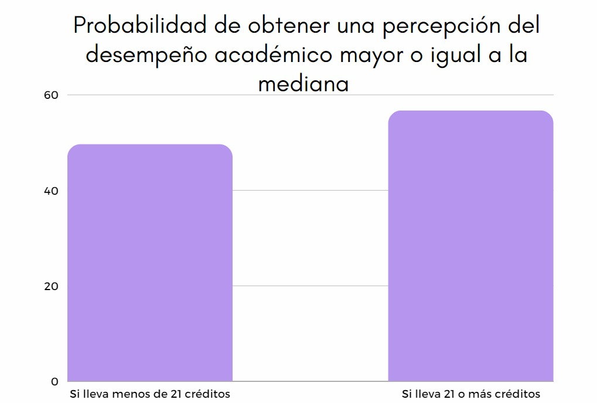

### 2) Respecto a la variable `Trabaja`

#### **¿Cuál es la probabilidad de obtener una percepción del desempeño académico superior o igual a 7 si un estudiante no trabaja?**

```r
N<-DatosG7$como_va_academic
H<-DatosG7$Trabaja
n<-nrow(DatosG7)

MedianN<-median(DatosG7$como_va_academic) #Mediana igual a 7
```

```r
(sum((N>=MedianN)&(H==2 ))/n)/(sum(H==2)/n)
```

```
## [1] 0.5104167
```

```r
# 51.04167%
```

#### **¿Cuál es la probabilidad de obtener una percepción del desempeño académico superior o igual a 7 si un estudiante trabaja?**

```r
N<-DatosG7$como_va_academic
H<-DatosG7$Trabaja
n<-nrow(DatosG7)

MedianN<-median(DatosG7$como_va_academic) #Mediana igual a 7
```

```r
(sum((N>=MedianN)&(H==1))/n)/(sum(H==1)/n)
```

```
## [1] 0.6666667
```

```r
# 66.66667%
```

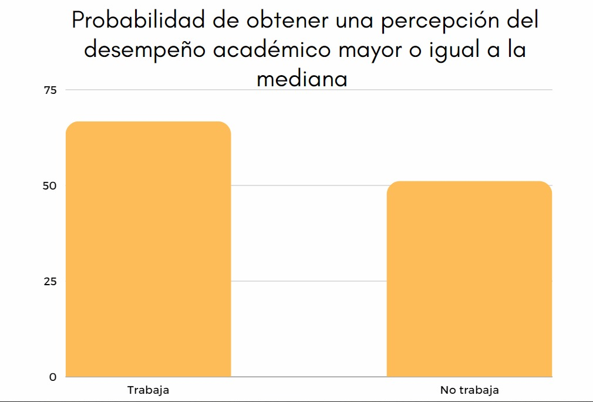

### 3) Respecto a la variable `temp_influye`

#### **¿Cuál es la probabilidad de obtener una percepción del desempeño académico superior o igual a 7 si un estudiante cree que la temperatura influye en su bienestar académico?**

```r
N<-DatosG7$como_va_academic
H<-DatosG7$temp_influye
n<-nrow(DatosG7)

MedianN<-median(DatosG7$como_va_academic) #Mediana igual a 7
```

```r
(sum((N>=MedianN)&(H==1 ))/n)/(sum(H==1)/n)
```

```
## [1] 0.5071429
```

```r
# 50.71429%
```

#### **¿Cuál es la probabilidad de obtener una percepción del desempeño académico superior o igual a 7 dado que un estudiante no cree que la temperatura influye en su bienestar académico?**

```r
N<-DatosG7$como_va_academic
H<-DatosG7$temp_influye
n<-nrow(DatosG7)

MedianN<-median(DatosG7$como_va_academic) #Mediana igual a 7
```

```r
(sum((N>=MedianN)&(H==2))/n)/(sum(H==2)/n)
```

```
## [1] 0.5616438
```

```r
# 56.16438%
```

Notamos que la probabilidad dada la primera condición es de 50.71%. Mientras que la probabilidad dada la segunda es de 56.16%. Es decir, es más probable que alguien que cree que la temperatura no influye en su bienestar académico tenga una buena percepción de su desempeño, a comparación de alguien que sí cree que influye. Lo que nos lleva a la conclusión que la percepción del desempeño académico va a depender si al estudiante le afecta o no la temperatura dentro de la universidad.

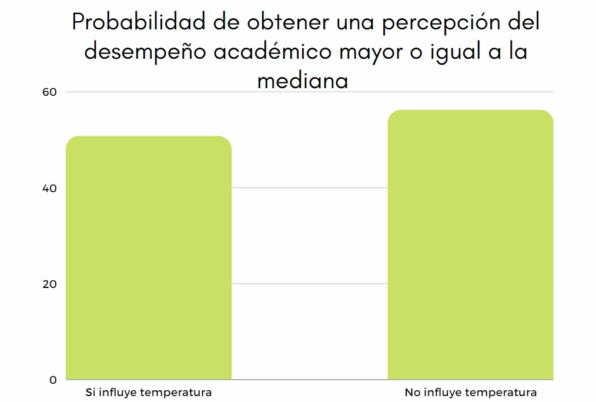

### 4) Respecto a la variable `Disp_piso_1`

#### **¿Cuál es la probabilidad de obtener una percepción del desempeño académico superior o igual a 7 si un estudiante tiene una percepción mayor a 6 respecto a la disponibilidad de la sala de estudios del piso 1?**

```r
N<-DatosG7$como_va_academic
H<-DatosG7$Disp_piso_1
n<-nrow(DatosG7)

MedianN<-median(DatosG7$como_va_academic) #Mediana igual a 7
```

```r
(sum((N>=MedianN)&(H>6))/n)/(sum(H>6)/n)
```

```
## [1] 0.75
```

```r
# 75%
```

```r
N<-DatosG7$como_va_academic
H<-DatosG7$Disp_piso_1
n<-nrow(DatosG7)

MedianN<-median(DatosG7$como_va_academic) #Mediana igual a 7
```

```r
(sum((N>=MedianN)&(H<=6))/n)/(sum(H<=6)/n)
```

```
## [1] 0.4739884
```

```r
# 47.39884%
```

Notamos que la probabilidad dada la primera condición es de 75%. Mientras que la probabilidad dada la segunda es de 47.4%. Es decir, es más probable que alguien que tenga una percepción mayor a 6 respecto a la disponibilidad del piso 1, tenga una buena percepción de su desempeño, a comparación de alguien con una percepción menor de disponibilidad. Lo que nos lleva a la conclusión que la percepción del desempeño académico se verá afectada positivamente si el estudiante se siente satisfecho con la disponibilidad de del piso 1.

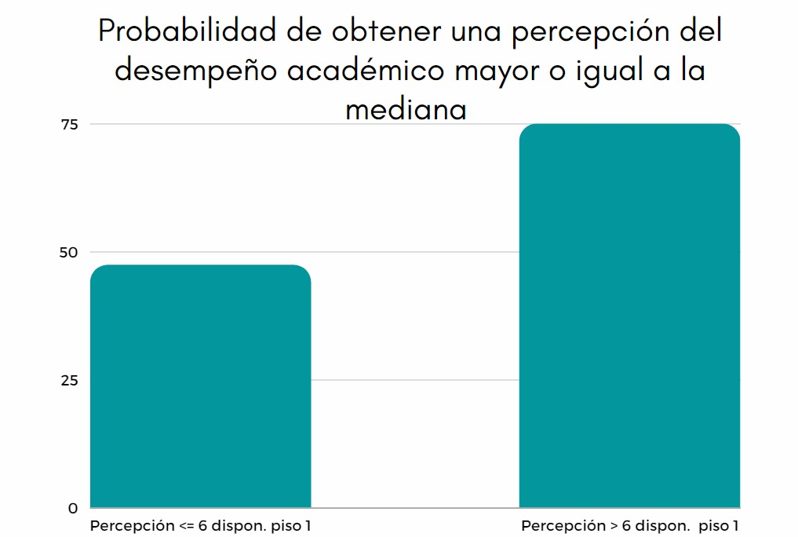

# **Conclusión**

## Trabajo en grupo

La experiencia de trabajo como equipo durante la segunda entrega fue muy enriquecedora y fortaleció nuestro trabajo colaborativo, en esta segunda parte afrontamos desafíos como disponibilidad de tiempo debido a la precisión de las últimas semanas de clases, lo resolvimos repartiendo bien nuestras tareas, el secreto está en hacer pequeños esfuerzos y separar espacios en nuestra agenda para las reuniones donde analizamos y designamos tareas.